# VarianceBias-OSCR-Functions

## Variance-Bias Tradeoff

**Vaidation Methods Module in Python**

**© Kaixin Wang**, Winter 2020

## Data Preprocessing

### Libraries Import

```python
import pandas as pd
import numpy as np
import matplotlib.pyplot as plt
import seaborn as sns
```

### Data Import

```python
# read in the csv file
train = pd.read_csv("football_train.csv", index_col = 0)
```

```python
# check if the file has been correctly read in
train.head()
```

| ID | Yards | OffensivePlays | TurnOversLost | FumblesLost | FirstDowns | PassesCompleted | PassesAttempted | YardsGainedPassing | InterceptionsThrown | RushingAttempts | ... | OppPassesAttempted | OppYardsGainedPassing | OppInterceptionsThrown | OppRushingAttempts | OppYardsGainedRushing | OppPenaltiesCommitedByTeam | OppPenaltiesInYards | OppFirstDownsByPenalty | OppNumberOfDrives | Wins |
| --- | --- | --- | --- | --- | --- | --- | --- | --- | --- | --- | --- | --- | --- | --- | --- | --- | --- | --- | --- | --- | --- |
| 1 | 5340 | 1000 | 31 | 11 | 275 | 298 | 519 | 3340 | 20 | 437 | ... | 549 | 4092 | 9 | 442 | 1727 | 87 | 686 | 28 | 189 | 4 |
| 2 | 6138 | 1014 | 25 | 14 | 342 | 328 | 476 | 3784 | 11 | 508 | ... | 558 | 4031 | 18 | 392 | 1650 | 104 | 861 | 34 | 179 | 12 |
| 3 | 5362 | 955 | 19 | 13 | 288 | 306 | 494 | 3361 | 6 | 431 | ... | 521 | 3216 | 19 | 444 | 2107 | 79 | 676 | 18 | 177 | 10 |
| 4 | 5728 | 1004 | 17 | 8 | 324 | 334 | 505 | 3923 | 9 | 467 | ... | 646 | 3976 | 21 | 344 | 1477 | 116 | 1063 | 31 | 180 | 12 |
| 5 | 4788 | 994 | 26 | 9 | 269 | 328 | 586 | 3419 | 17 | 358 | ... | 535 | 3832 | 12 | 545 | 2256 | 101 | 820 | 37 | 191 | 2 |

5 rows × 31 columns

```python
train.shape
```

```
(380, 31)
```

```python
# standardize the numeric columns
n = train.shape[1]
for i in range(n - 1):
    train.iloc[:, i] = (train.iloc[:, i] - np.mean(train.iloc[:, i])) / np.std(train.iloc[:, i])
```

```python
train.head()
```

| ID | Yards | OffensivePlays | TurnOversLost | FumblesLost | FirstDowns | PassesCompleted | PassesAttempted | YardsGainedPassing | InterceptionsThrown | RushingAttempts | ... | OppPassesAttempted | OppYardsGainedPassing | OppInterceptionsThrown | OppRushingAttempts | OppYardsGainedRushing | OppPenaltiesCommitedByTeam | OppPenaltiesInYards | OppFirstDownsByPenalty | OppNumberOfDrives | Wins |
| --- | --- | --- | --- | --- | --- | --- | --- | --- | --- | --- | --- | --- | --- | --- | --- | --- | --- | --- | --- | --- | --- |
| 1 | -0.067486 | -0.275791 | 0.797903 | 0.138608 | -0.874948 | -0.619963 | -0.305416 | -0.325343 | 1.009883 | -0.041968 | ... | 0.178948 | 1.276131 | -1.386068 | 0.172824 | -0.262938 | -1.136733 | -1.345573 | 0.161351 | 0.268029 | 4 |
| 2 | 1.198873 | 0.018357 | -0.084356 | 0.965899 | 0.907859 | -0.009847 | -1.013489 | 0.384790 | -0.836082 | 1.296434 | ... | 0.382406 | 1.132749 | 0.485370 | -0.909461 | -0.521518 | 0.077035 | 0.009290 | 0.978862 | -0.740398 | 12 |
| 3 | -0.032574 | -1.221267 | -0.966615 | 0.690135 | -0.529030 | -0.457266 | -0.717086 | -0.291755 | -1.861618 | -0.155072 | ... | -0.454033 | -0.782929 | 0.693308 | 0.216115 | 1.013175 | -1.707917 | -1.422994 | -1.201168 | -0.942083 | 10 |
| 4 | 0.548237 | -0.191749 | -1.260702 | -0.688684 | 0.428896 | 0.112176 | -0.535951 | 0.607106 | -1.246296 | 0.523554 | ... | 2.371773 | 1.003470 | 1.109183 | -1.948455 | -1.102485 | 0.933812 | 1.573190 | 0.570106 | -0.639555 | 12 |
| 5 | -0.943463 | -0.401855 | 0.062687 | -0.412920 | -1.034602 | -0.009847 | 0.797860 | -0.198990 | 0.394561 | -1.531175 | ... | -0.137542 | 0.664994 | -0.762256 | 2.402332 | 1.513546 | -0.137159 | -0.308135 | 1.387617 | 0.469715 | 2 |

5 rows × 31 columns

### Correlation matrix and correlation heatmap

```python
train.corr().iloc[:, n-1]
```

```
Yards                         0.545436
OffensivePlays                0.275029
TurnOversLost                -0.531927
FumblesLost                  -0.329564
FirstDowns                    0.527665
PassesCompleted               0.141868
PassesAttempted              -0.091427
YardsGainedPassing            0.363565
InterceptionsThrown          -0.496850
RushingAttempts               0.449488
YardsGainedRushing            0.342025
PenaltiesCommitedByTeam      -0.171125
PenaltiesInYards             -0.138735
FirstDownsByPenalty           0.172522
NumberOfDrives               -0.126591
OppYards                     -0.361141
OppOffensivePlays            -0.214024
OppTurnOversLost              0.441954
OppFumblesLost                0.194505
OppFirstDowns                -0.307572
OppPassesCompleted            0.090255
OppPassesAttempted            0.367913
OppYardsGainedPassing        -0.117004
OppInterceptionsThrown        0.452108
OppRushingAttempts           -0.631873
OppYardsGainedRushing        -0.464723
OppPenaltiesCommitedByTeam    0.044104
OppPenaltiesInYards           0.056435
OppFirstDownsByPenalty       -0.064709
OppNumberOfDrives            -0.136681
Wins                          1.000000
Name: Wins, dtype: float64
```

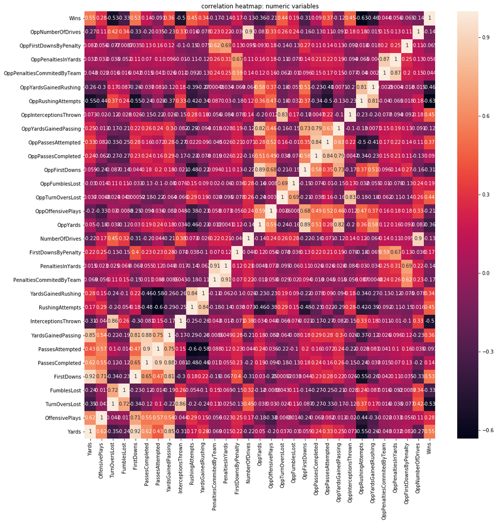

```python
plt.figure(figsize=(16,16))
sns.heatmap(train.corr(), annot = True)
plt.xlim([0, n])
plt.ylim([0, n])
plt.title("correlation heatmap: numeric variables")
plt.show()
```

```python
indices = []
for i in range(n-1):
    if (abs(train.corr().iloc[:, n-1]) > 0.35)[i]:
        indices.append(i)
```

## Validation Methods

### Train-Test-Split Method

Suppose that we want to predict the variable `Wins` of each team based on the predictors in the dataframe.

Therefore, to enhance the predictive ability of the model, we split the dataset into a **training set** and a **testing set**:

- training set: used to build the model (i.e., obtain the coefficients of the model)
- testing set: used to test how good the model is (i.e., to test if the model is overfitting data observed)

Since there are 380 observations in the data frame `train`, we can use the 70%/30% split method, where 70% of the entries will serve as the training set while the other 30% will be the testing set.

There are two methods to split the dataset:

1. using the `train_test_split` function in `scikit-learn` module
2. using the random number generator `sample` function in `random` module

#### train_test_split() function

```python
# import the function from module
from sklearn.model_selection import train_test_split
```

```python
X = train.iloc[:, range(0, n-1)]
y = train.iloc[:, n-1]
```

```python
X_train, X_test, y_train, y_test = train_test_split(X, y, test_size = 0.3, random_state = 42)
print("size of the training set is %d, size of the testing set is %d." %(X_train.shape[0], X_test.shape[0]))
```

```
size of the training set is 266, size of the testing set is 114.
```

#### sample() function

Note: this method takes relatively more steps than using the `train_test_split()` function.

```python
import random
start = 0
end = X.shape[0]
size = X.shape[0]
# obtain the indices of training set
train_indices = random.sample(range(start, end), int(size * 0.7))
```

```python
# to obtain the indices for testing set
test_indices = list(set(range(start, end)) - set(train_indices))
```

```python
train_X = X.iloc[train_indices, :]
train_y = y.iloc[train_indices]
test_X = X.iloc[test_indices, :]
test_y = y.iloc[test_indices]
```

```python
print("size of the training set is %d, size of the testing set is %d." %(train_X.shape[0], test_X.shape[0]))
```

```
size of the training set is 266, size of the testing set is 114.
```

```python
# check if there is any duplicates in two dataframes
print(test_indices in train_indices)
print(train_indices in test_indices)
```

```
False
False
```

### Variance-Bias Tradeoff

- Variance: the variance of the predicted values.
- Bias: the expected difference between the predicted value and the actual value for the new values of x.

```python
import statsmodels.api as sm # another package for linear model
import statsmodels.formula.api as smf
```

```python
# create a dataframe for both the training and the testing
df_train = pd.concat([X_train, y_train], axis = 1)
# linear regression model using statsmodel
model1 = smf.ols("Wins ~ Yards + TurnOversLost + FirstDowns + InterceptionsThrown + OppYardsGainedRushing", data = df_train)
results = model1.fit()
print(results.summary())
```

```
                            OLS Regression Results
==============================================================================
Dep. Variable:                   Wins   R-squared:                       0.542
Model:                            OLS   Adj. R-squared:                  0.533
Method:                 Least Squares   F-statistic:                     61.58
Date:                Mon, 10 Feb 2020   Prob (F-statistic):           3.54e-42
Time:                        12:30:17   Log-Likelihood:                -579.86
No. Observations:                 266   AIC:                             1172.
Df Residuals:                     260   BIC:                             1193.
Df Model:                           5
Covariance Type:            nonrobust
=========================================================================================
                            coef    std err          t      P>|t|      [0.025      0.975]
-----------------------------------------------------------------------------------------
Intercept                 8.1851      0.133     61.483      0.000       7.923       8.447
Yards                     0.5655      0.342      1.653      0.100      -0.108       1.239
TurnOversLost            -0.5980      0.259     -2.308      0.022      -1.108      -0.088
FirstDowns                0.6908      0.351      1.970      0.050       0.000       1.381
InterceptionsThrown      -0.4586      0.249     -1.843      0.067      -0.949       0.031
OppYardsGainedRushing    -0.9874      0.133     -7.397      0.000      -1.250      -0.725
==============================================================================
Omnibus:                        1.232   Durbin-Watson:                   1.848
Prob(Omnibus):                  0.540   Jarque-Bera (JB):                1.281
Skew:                          -0.100   Prob(JB):                        0.527
Kurtosis:                       2.725   Cond. No.                         5.88
==============================================================================

Warnings:
[1] Standard Errors assume that the covariance matrix of the errors is correctly specified.
```

```python
model2 = smf.ols("Wins ~ Yards + TurnOversLost + FirstDowns", data = df_train)
results2 = model2.fit()
print(results2.summary())
```

```
                            OLS Regression Results
==============================================================================
Dep. Variable:                   Wins   R-squared:                       0.439
Model:                            OLS   Adj. R-squared:                  0.432
Method:                 Least Squares   F-statistic:                     68.27
Date:                Mon, 10 Feb 2020   Prob (F-statistic):           1.19e-32
Time:                        12:30:17   Log-Likelihood:                -606.96
No. Observations:                 266   AIC:                             1222.
Df Residuals:                     262   BIC:                             1236.
Df Model:                           3
Covariance Type:            nonrobust
=================================================================================
                    coef    std err          t      P>|t|      [0.025      0.975]
---------------------------------------------------------------------------------
Intercept         8.1642      0.147     55.612      0.000       7.875       8.453
Yards             0.6789      0.377      1.802      0.073      -0.063       1.421
TurnOversLost    -1.0858      0.155     -7.018      0.000      -1.390      -0.781
FirstDowns        0.8202      0.386      2.124      0.035       0.060       1.581
==============================================================================
Omnibus:                        2.060   Durbin-Watson:                   1.911
Prob(Omnibus):                  0.357   Jarque-Bera (JB):                2.030
Skew:                          -0.153   Prob(JB):                        0.362
Kurtosis:                       2.700   Cond. No.                         5.21
==============================================================================

Warnings:
[1] Standard Errors assume that the covariance matrix of the errors is correctly specified.
```

```python
# true test set
test_x = pd.read_csv("football_test.csv", index_col = 0)
test_y = pd.read_csv("football_answers.csv")
```

```python
# standardize the features
n = test_x.shape[1]
for i in range(n - 1):
    test_x.iloc[:, i] = (test_x.iloc[:, i] - np.mean(test_x.iloc[:, i])) / np.std(test_x.iloc[:, i])
```

```python
from sklearn.linear_model import LinearRegression
```

```python
model1_indices = [0, 2, 4, 8, 25]
model2_indices = [0, 2, 4]
```

```python
model1 = LinearRegression().fit(X_train.iloc[:, model1_indices], y_train)
pred1 = model1.predict(X.iloc[:, model1_indices])
model2 = LinearRegression().fit(X_train.iloc[:, model2_indices], y_train)
pred2 = model2.predict(X.iloc[:, model2_indices])
```

```python
model1.coef_
```

```
array([ 0.56553607, -0.59798115,  0.69075096, -0.4586361 , -0.98742599])
```

```python
model2.coef_
```

```
array([ 0.67893791, -1.08579519,  0.82022425])
```

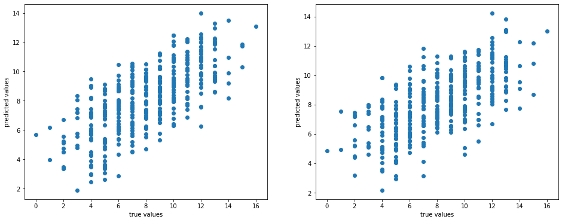

```python
nrows = X.shape[0]
plt.figure(figsize = (16, 6))
plt.subplot(1, 2, 1)
plt.scatter(y, pred1)
plt.xlabel("true values")
plt.ylabel("predicted values")
plt.subplot(1, 2, 2)
plt.scatter(y, pred2)
plt.xlabel("true values")
plt.ylabel("predicted values")
plt.show()
```

Now we will fit multiple models on the training set and see the model performance on the dataset:

#### Building Linear Regression Models with different complexities

```python
indices
```

```
[0, 2, 4, 7, 8, 9, 15, 17, 21, 23, 24, 25]
```

```python
# to generate all possible combinations of the indices
import itertools
```

```python
def createMLRModel(train_X, train_y, test_X, indices, complexity):
    '''
    This function creates a Multiple Linear Regression Model based on the input
    dataframes, indices of the predictors, and the complexity of the model.
    train_X: training set of the predictors
    train_y: training set of the outcome
    test_X: testing set of the predictors
    indices: index of each predictor used in the modeling
    complexity: number of predictors required
    return: predictions - a list of list that contains the predictions of each model
    '''
    predictions = []
    for subset in itertools.combinations(indices, complexity):
        model = LinearRegression().fit(train_X.iloc[:, list(subset)], train_y)
        pred = model.predict(test_X.iloc[:, list(subset)])
        predictions.append(pred.reshape(1,-1))
    return predictions
```

**Create regression models and obtain the predictions**

```python
predictions = {}
for i in range(1, 10):
    predictions[i] = createMLRModel(X_train, y_train, test_x, indices, i)
    print("%d MLR models built with complexity = %d" %(len(predictions[i]), i))
```

```
12 MLR models built with complexity = 1
66 MLR models built with complexity = 2
220 MLR models built with complexity = 3
495 MLR models built with complexity = 4
792 MLR models built with complexity = 5
924 MLR models built with complexity = 6
792 MLR models built with complexity = 7
495 MLR models built with complexity = 8
220 MLR models built with complexity = 9
```

**Calculate the average value of predictions at each complexity level**

```python
averages = {}
for i in range(1, 10):
    averages[i] = list(np.mean(predictions[i], axis = 0)[0])
```

**Calculate the bias of predictions at each complexity level**

```python
test_y = test_y.loc[:, "Wins"]
```

```python
biases = {}
for i in range(1, 10):
    biases[i] = np.mean(np.abs(averages[i] - test_y))
```

**Calculate the average value of variance in predictions at each complexity level**

```python
variances = {}
for i in range(1, 10):
    variances[i] = np.mean(np.var(predictions[i]))
```

**Visualize the decrease in bias as the complexity level increases**

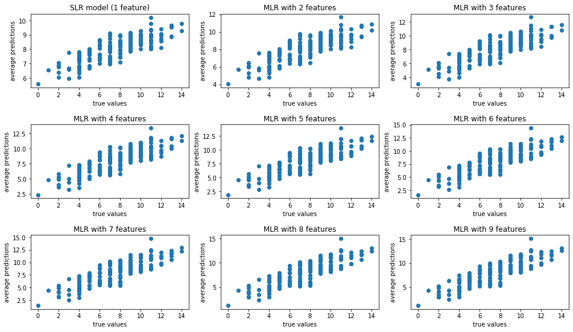

```python
nrows = test_y.shape[0]
plt.figure(figsize = (16, 9))
plt.subplots_adjust(hspace = 0.5)
for i in range(9):
    plt.subplot(3, 3, i+1)
    plt.scatter(test_y, averages[i+1])
    plt.xlabel("true values")
    plt.ylabel("average predictions")
    if i == 0:
        plt.title("SLR model (1 feature)")
    else:
        plt.title("MLR with %d features" %(i+1))
```

**Bias vs. model complexity**

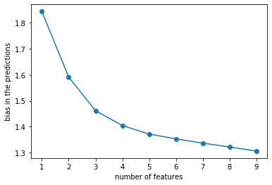

```python
plt.plot(list(biases.keys()), list(biases.values()),"-o")
plt.xlabel("number of features")
plt.ylabel("bias in the predictions")
plt.show()
```

**Variance vs. model complexity**

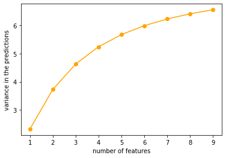

```python
plt.plot(list(variances.keys()), list(variances.values()),"-o", color = "orange")
plt.xlabel("number of features")
plt.ylabel("variance in the predictions")
plt.show()
```

**Bias vs. Variance as model complexity increases**

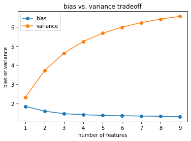

```python
plt.plot(list(biases.keys()), list(biases.values()),"-o")
plt.plot(list(variances.keys()), list(variances.values()),"-o")
plt.xlabel("number of features")
plt.ylabel("bias or variance")
plt.legend(["bias", "variance"])
plt.title("bias vs. variance tradeoff")
plt.show()
```

Upcoming modules:

### Tree-based Methods

- Regression Trees and Classfication Trees
- Boosting-based Trees:
  - XGBoost
  - LightGBM
- Bagging-based Trees:
  - Random Forest

### Evaluation Criteria

- MSE and RMSE
- $R^2$ and $R^2_{\text{adj}}$
- AIC, BIC and $C_p$

**© Kaixin Wang**, updated February 2020